# STS 112: Lab 7

James Chapman

This week, you read about migration from the South to the North and West over the twentieth century. As you noticed in the reading, the experience of black and white migrants differed in some ways and was similar in other ways. In this lab, you are going to make two sets of maps covering the years 1900, 1930, 1960, and 1990. One will show the proportion of African Americans in each state who were born in the South. The other will show the proportion of white Americans in each state who were born in the South. For each map, think carefully about what is the numerator and what is the denominator.

Start by loading the packages you will need (the same ones we used for the lab). Then read in the data for Week 7, saving as `ipums` (eliminate rows outside the contiguous 48 states), and use the `states()` function from the `tigris` package to get the state geography simple features data frame, saving as `states`.

```r
library(tidyverse)
```

```r
library(sf)
```

```r
library(tigris)
```

```r
library(viridis)
```

```r
library(cowplot)
```

```r
ipums <- read_csv("wk7.csv") %>% filter(!STATEFIP %in% c(2,15) & STATEFIP <= 56)
```

```r
states <- states(class = "sf")
```

In contrast to this week’s notebook, where we had to make two separate sets of maps, for the lab, we can make a single plot that is faceted horizontally by race and vertically by year. We can do this because we are plotting the same thing (percent born in the South) for African Americans and for white Americans.

## Identifying southern-born by race

Start by making a vector called `south` that includes the `STATEFIP` codes for all states in the South (this is 16 states, plus the District of Columbia) You can consult the [Census Bureau](https://www2.census.gov/geo/docs/maps-data/maps/reg_div.txt) for the full list of states and codes.

```r
south <- c(1, 5, 10:13, 21, 22, 24, 28, 37, 40, 45, 47, 48, 51, 54)
```

Now decide how you will classify individuals as either white or black. Create a new data frame called `ipums_sub` that includes only people who fall into one of those categories. In the same data frame, create a new factor variable called `RACEF` that classifies individuals as either white or black, and includes text labels indicating race. Test your new variable.

```r
ipums_sub <- ipums %>% filter(RACE == 1 | RACE == 2) %>% mutate(RACEF = ifelse(RACE == 1, "White", "Black"))
#Don't forget to test!
table(ipums_sub$RACEF, ipums_sub$RACE)
```

```
               1        2
  Black        0  1696059
  White 13582101        0
```

In your `ipums_sub` data frame, create a new variable called `SBORN` that takes a value of `TRUE` if a person was born in the South and `FALSE` otherwise. Test to make sure this is working correctly.

```r
ipums_sub = ipums_sub %>% mutate(SBORN = ifelse(BPL %in% south, TRUE, FALSE))

table(ipums_sub$BPL, ipums_sub$SBORN)
```

```
        FALSE    TRUE
  1         0  316220
  2      7798       0
  4     78293       0
  5         0  199623
  6    792816       0
  8    137638       0
  9    170366       0
  10        0   33182
  11        0   69770
  12        0  303751
  13        0  406519
  15    10089       0
  16    58027       0
  17   786709       0
```

[output cut: 140 more lines]

## Calculating percentages

Now create a new variable called `PCT` that indicates the percent of people, within each unique combination of `YEAR`, `STATEFIP`, and `RACEF` that was born in the South. Remember to put denominator variables in `group_by()` and numerator variables in `count()` Don’t forget to weight by `PERWT`.

```r
ipums_sub <- ipums_sub %>% group_by(YEAR, STATEFIP, RACEF) %>%
                            count(SBORN, wt = PERWT)  %>% mutate(TOTAL = sum(n)) %>%
                            mutate(PCT = n/TOTAL)
head(ipums_sub)
```

| YEAR | STATEFIP | RACEF | SBORN | n | TOTAL | PCT |
| --- | --- | --- | --- | --- | --- | --- |
| 1900 | 1 | Black | FALSE | 903 | 844829 | 0.001068855 |
| 1900 | 1 | Black | TRUE | 843926 | 844829 | 0.998931145 |
| 1900 | 1 | White | FALSE | 34189 | 996977 | 0.034292667 |
| 1900 | 1 | White | TRUE | 962788 | 996977 | 0.965707333 |
| 1900 | 4 | Black | FALSE | 302 | 702 | 0.430199430 |
| 1900 | 4 | Black | TRUE | 400 | 702 | 0.569800570 |

Now ungroup and drop the rows that represent percent of people not born in the South.

```r
ipums_sub <- ipums_sub %>% ungroup() %>% filter(SBORN)
```

## Joining

Create a new object called `ipums_map` by joining `ipums_sub` to the `states` simple features data frame. Convert this new object to a simple features data frame.

```r
states$STATEFIP <- as.numeric(states$STATEFP)
ipums_map <- inner_join(ipums_sub, states) %>% st_as_sf()
```

## Continuous map

Create a set of maps that shows the percent of people who were born in the South on a continuous scale. Facet horizontally (columns) by race and vertically (rows) by year. Use a color scheme where lighter colors indicate fewer people. Include all of the layers you need to make these maps publication quality.

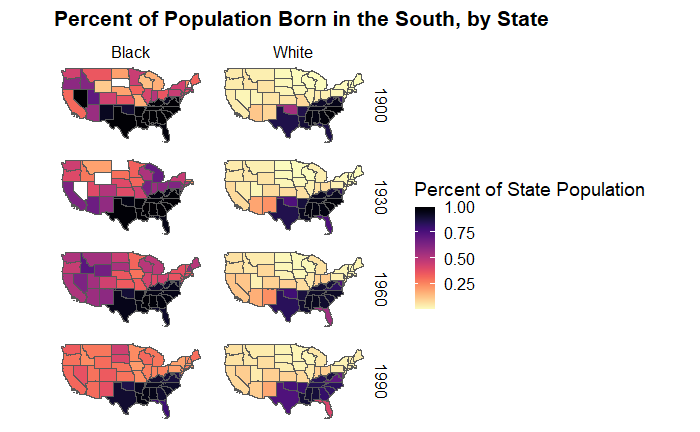

```r
map_south <- ggplot(ipums_map, aes(fill = PCT)) + geom_sf() +
              labs(title = "Percent of Population Born in the South, by State", fill = "Percent of State Population") +
              theme_map() +
              coord_sf(datum = NA) +
              facet_grid(rows = vars(YEAR), cols = vars(RACEF)) +
              scale_fill_viridis(option = "magma", direction = -1)

map_south
```

## Discrete map

Now make the same map using a discrete scale. This will require creating a new variable (call it `PCTD`) that classifies each value of `PCT` among a set of discrete bins. You can use as many bins as you want and define them however you want.

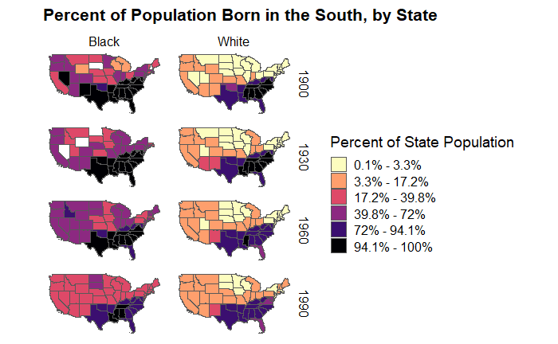

```r
classes <- 6
labels <- c()
quantiles <- quantile(ipums_map$PCT, probs = seq(0, 1, 1/classes))

for (i in 1:length(quantiles)) {
  labels <- c(labels, paste0(round(quantiles[i]*100, 1), "% - ", round(quantiles[i+1]*100, 1), "%"))
}

labels <- labels[-length(labels)]




ipums_map <- ipums_map %>% mutate(PCTD = cut(ipums_map$PCT, breaks = quantiles, labels = labels, include.lowest = TRUE)) %>%
                mutate(PCTD = factor(PCTD, labels = labels))

ggplot(ipums_map, aes(fill = PCTD)) + geom_sf() +
              labs(title = "Percent of Population Born in the South, by State", fill = "Percent of State Population") +
              theme_map() +
              coord_sf(datum = NA) +
              facet_grid(rows = vars(YEAR), cols = vars(RACEF)) +
              scale_fill_viridis(option = "magma", discrete = T, direction = -1)
```

Make sure all of your code and results are showing and submit your Lab on Canvas.